# Assignment 3 - CRD

Author

Chris Nieters

# Introduction

This assignment will ask you to conduct a full CRD analysis, from data import through publication ready plot.

The different sections representing what we did in class were left in the script to provide you a scaffold to start from.

# Instructions

- Move this script into the `code` subfolder of your `03_crd` project folder
- Move the file `wheat_nk_bamyan.csv` into the `data` folder of your `03_crd` project folder
- On this script, fill your name under the `title` section of the YAML

# a) Setup

Here is where we load the packages we will use.  
Make sure to load each package in the chunk below.

```r
library(tidyverse)
library(car) # for Anova function
library(broom) # for model residuals extraction
library(emmeans) # for model mean extraction
library(multcomp) # for pairwise comparison letter display
library(multcompView)
library(ggsci)
```

Now, import the data set `wheat_nk_bamyan.csv` in the chunk below.

```r
crd_df <- read.csv("../data/wheat_nk_bamyan.csv")
```

The **objective of this study** was to assess the effect of different N and K rates on wheat yield.

For that, a study was conducted using a completely randomized design as the experimental design with four replicates. The treatment design was a 3 N x 3 K rate factorial, for a total of 9 treatments.

# b) EDA tables

Use this space to conduct exploratory data analysis of the imported data, in the form of tables.

```r
summary(crd_df)
```

```
      trt         rep         nrate_kgha    krate_kgha   yield_kgha
 Min.   :1   Min.   :1.00   Min.   :  0   Min.   : 0   Min.   : 812
 1st Qu.:3   1st Qu.:1.75   1st Qu.:  0   1st Qu.: 0   1st Qu.:2630
 Median :5   Median :2.50   Median :100   Median :30   Median :3750
 Mean   :5   Mean   :2.50   Mean   :100   Mean   :30   Mean   :3838
 3rd Qu.:7   3rd Qu.:3.25   3rd Qu.:200   3rd Qu.:60   3rd Qu.:5238
 Max.   :9   Max.   :4.00   Max.   :200   Max.   :60   Max.   :7232
```

```r
glimpse(crd_df)
```

```
Rows: 36
Columns: 5
$ trt        <int> 1, 2, 3, 4, 5, 6, 7, 8, 9, 1, 2, 3, 4, 5, 6, 7, 8, 9, 1, 2,…
$ rep        <int> 1, 1, 1, 1, 1, 1, 1, 1, 1, 2, 2, 2, 2, 2, 2, 2, 2, 2, 3, 3,…
$ nrate_kgha <int> 0, 0, 0, 100, 100, 100, 200, 200, 200, 0, 0, 0, 100, 100, 1…
$ krate_kgha <int> 0, 30, 60, 0, 30, 60, 0, 30, 60, 0, 30, 60, 0, 30, 60, 0, 3…
$ yield_kgha <int> 1350, 2110, 5725, 2988, 3438, 6525, 2825, 4400, 7025, 2250,…
```

# c) Wrangling

Here, make sure to wrangle your data set with all needed steps. Refer back to class code if you need a refresher on what was needed.

```r
crd_dfw <- crd_df |>
  mutate_at(
    vars(krate_kgha,nrate_kgha,rep), as.factor)|>
  mutate(
    trt_name = paste0(krate_kgha,"+",nrate_kgha)
  )
```

# d) EDA plots

Now, explore the wrangled data using plots.  
Make sure to explore plots showing the main effects and the interaction.

## N effects boxplot

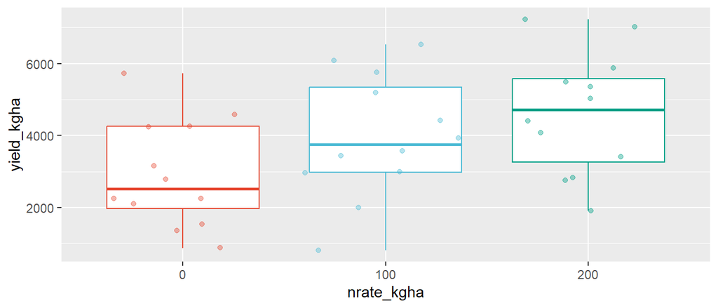

## K effects boxplot

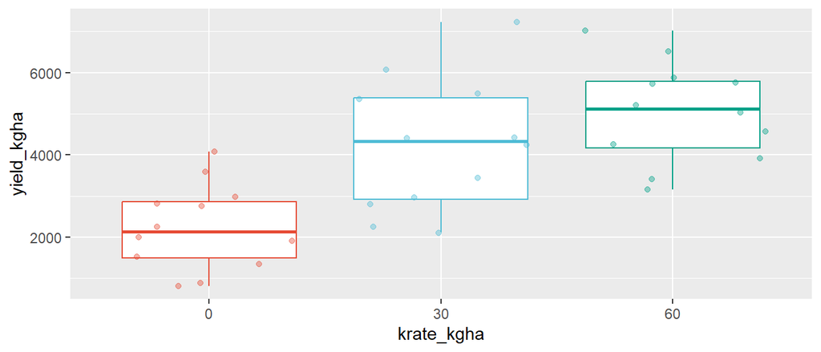

- This plot indicates that there is an initial linear response in yield from increasing K fertilizer rate from 0 to 30 kg/ha, but adding 60 kg/ha has a less pronounced effect.

## N + K effects boxplot

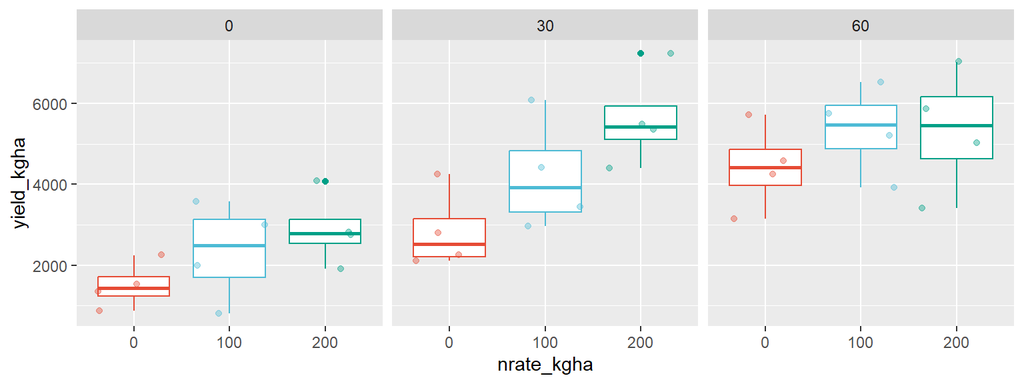

- This plot indicates that there are different yield responses to N application rate depending on the amount of K applied with it - differences in yield responses to N application amount appear to be most pronounced when also applied with 30 kg/ha of K.

## Question 1) Below each plot of this section, write a sentence explaining your visual interpretation of the plot.

# e) Statistical model

In this section, run the appropriate model.  
Remember to set the contrast type to sum-to-zero (the default in R is set-to-zero, which is not what we want).

```r
# Changing to sum-to-zero contrast
options(contrasts = c("contr.sum", "contr.poly"))

# attach dataframe to include in model
attach(crd_dfw)

# Model fitting
crd_mod <- lm(yield_kgha ~ nrate_kgha*krate_kgha)

# Summary
summary(crd_mod)
```

```
Call:
lm(formula = yield_kgha ~ nrate_kgha * krate_kgha)

Residuals:
    Min      1Q  Median      3Q     Max
-1922.0  -656.1  -133.0   669.8  1851.5

Coefficients:
                        Estimate Std. Error t value Pr(>|t|)
(Intercept)              3837.94     188.07  20.407  < 2e-16 ***
nrate_kgha1              -911.61     265.97  -3.427  0.00197 **
nrate_kgha2               134.89     265.97   0.507  0.61616
krate_kgha1             -1591.78     265.97  -5.985  2.2e-06 ***
krate_kgha2               392.81     265.97   1.477  0.15128
nrate_kgha1:krate_kgha1   168.44     376.14   0.448  0.65785
nrate_kgha2:krate_kgha1   -37.06     376.14  -0.099  0.92225
nrate_kgha1:krate_kgha2  -468.89     376.14  -1.247  0.22326
nrate_kgha2:krate_kgha2  -142.14     376.14  -0.378  0.70847
---
Signif. codes:  0 '***' 0.001 '**' 0.01 '*' 0.05 '.' 0.1 ' ' 1

Residual standard error: 1128 on 27 degrees of freedom
Multiple R-squared:  0.6737,    Adjusted R-squared:  0.577
F-statistic: 6.969 on 8 and 27 DF,  p-value: 5.675e-05
```

Also, remember to specify all model terms needed for the treatment design.

- Model terms needed for this treatment design should include N effect, K effect, and N+K interaction effect. Since we are not using RCBD design, there is no need to include a blocking term.

# f) ANOVA table

Use this section to check the ANOVA table, ensuring you use type 3 sum-of-squares.

```r
car::Anova(crd_mod, type = 3)
```

```
Anova Table (Type III tests)

Response: yield_kgha
                         Sum Sq Df  F value    Pr(>F)
(Intercept)           530273432  1 416.4464 < 2.2e-16 ***
nrate_kgha             17430327  2   6.8444   0.00394 **
krate_kgha             49507045  2  19.4400 5.892e-06 ***
nrate_kgha:krate_kgha   4051423  4   0.7954   0.53857
Residuals              34379890 27
---
Signif. codes:  0 '***' 0.001 '**' 0.01 '*' 0.05 '.' 0.1 ' ' 1
```

## Question 2) Based on the ANOVA table above, for which effect(s) in the ANOVA should you extract means and perform pair-wise comparisons? Explain why.

- Based on the results of the ANOVA table above, the only significant effects were N application rate and K application rate - there was no significant interaction effect between these two factors. For this reason, means and pair-wise comparisons should be done on N and K application rates separately.

## Models for individual predictors

### N rate model

```r
#model for N rate
crd_modn <- lm(yield_kgha ~ nrate_kgha)
#ANOVA for N rate
Anova(crd_modn, type = 3)
```

```
Anova Table (Type III tests)

Response: yield_kgha
               Sum Sq Df  F value   Pr(>F)
(Intercept) 530273432  1 198.9919 1.57e-15 ***
nrate_kgha   17430327  2   3.2705  0.05061 .
Residuals    87938359 33
---
Signif. codes:  0 '***' 0.001 '**' 0.01 '*' 0.05 '.' 0.1 ' ' 1
```

### K rate model

```r
#model for K rate
crd_modk <- lm(yield_kgha ~ krate_kgha)
#ANOVA for K rate
Anova(crd_modk, type = 3)
```

```
Anova Table (Type III tests)

Response: yield_kgha
               Sum Sq Df F value    Pr(>F)
(Intercept) 530273432  1 313.257 < 2.2e-16 ***
krate_kgha   49507045  2  14.623 2.836e-05 ***
Residuals    55861641 33
---
Signif. codes:  0 '***' 0.001 '**' 0.01 '*' 0.05 '.' 0.1 ' ' 1
```

# g) Linear model assumptions

Use this section to first compute your residuals, including studentdized residuals.

```r
#calc studentized residuals N
crd_residn <- broom::augment(crd_modn) |>
  mutate(
    .stud_resid = rstudent(crd_modn)
  )

#calc studentized residuals K
crd_residk <- broom::augment(crd_modk) |>
  mutate(
    .stud_resid = rstudent(crd_modk)
  )

#combine residual tables
combined_resid <- crd_residn |>
  full_join(crd_residk)|>
  pivot_longer(
    c(2,10),
    names_to = "element",
    values_to = "rate_kgha"
  ) |>
  drop_na()
```

## Question 3) What are the linear model assumptions that we need to check for? Create subsections (using ##) below for each of these assumptions, and write code to produce plots to check for these assumptions. For each assumption, write down your interpretation of the produced plots, and your thoughts if the assumptions hold or not.

### Assumption 1: Residual independence

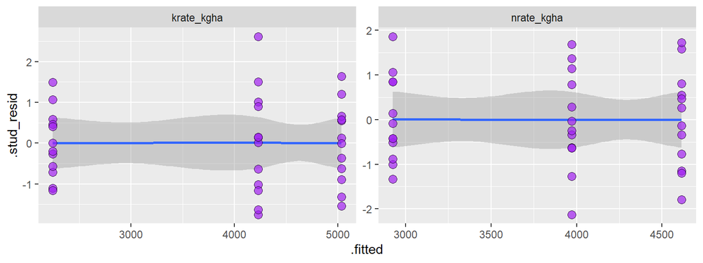

### Assumption 2: Residual homoscedasticity

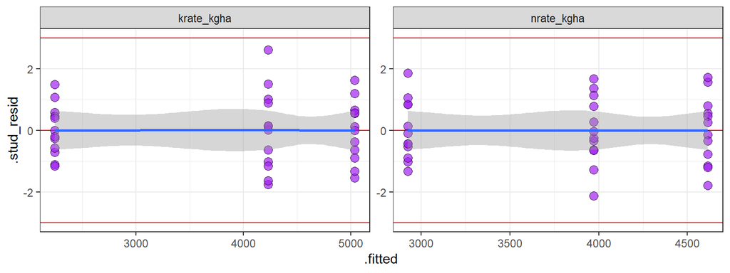

### Assumption 3: Residual normality

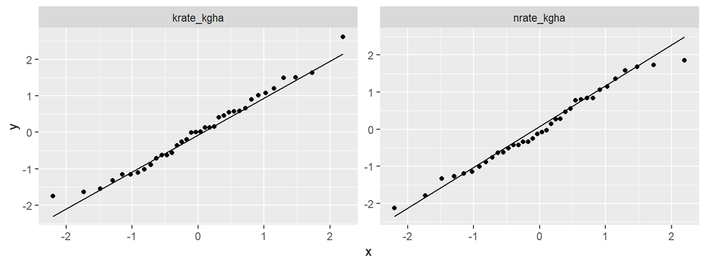

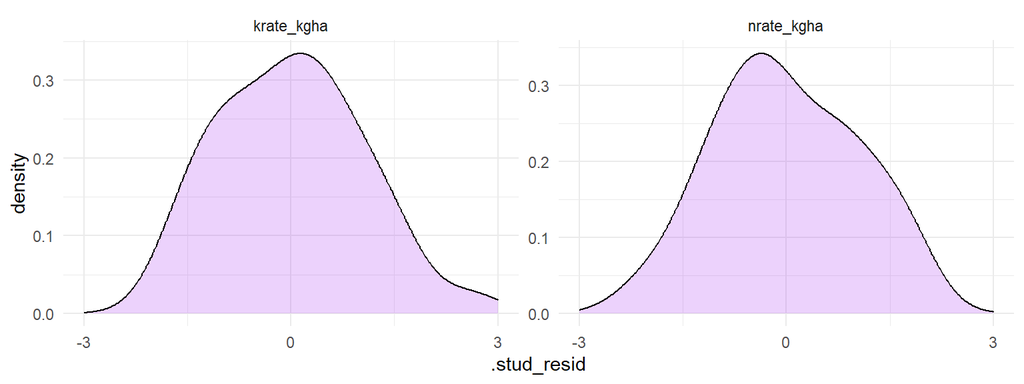

### Assumption 4: Residual outliers

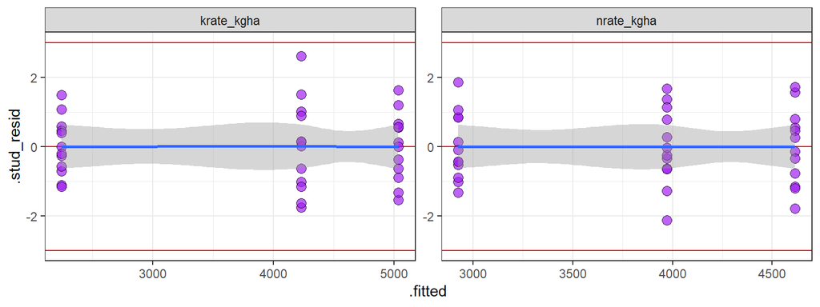

# h) Model means

Use this section to extract model means according to your decision of the ANOVA table effects.

## Extract model means

```r
#extract estimated marginal means N
crd_meansn <- emmeans::emmeans(crd_modn,
                                  ~nrate_kgha)

#extract estimated marginal means K
crd_meansk <- emmeans::emmeans(crd_modk,
                                  ~krate_kgha)
```

# i) Pairwise comparisons

Use this section to perform pair-wise comparison of the means extracted above.

```r
#compact letter display N
crd_cldn <- cld(crd_meansn,
                   reversed=T,
                   adjust="none",
               Letters=letters)

#compact letter display K
crd_cldk <- cld(crd_meansk,
                   reversed=T,
                   adjust="none",
               Letters=letters)

#combine objects for wrangling and plotting next
combined_cldk <- crd_cldn |>
  full_join(crd_cldk)
```

Make sure to reverse the order from high to low, use letters instead of numbers, and no adjustment.

# g) Final plot(s)

Produce final plot(s) to show your results.  
Make sure to include both **raw data** and **statistical model summary (i.e., letter separation)**.

Be mindful of your plot to ensure you are creating it in an intuitive way for your audience in relation to interpreting the letter separation structure you used.

In class, we did not have time to make it publication-ready (e.g., a plot looking professional and ready to be included in a manuscript).

Here, make sure you deliver final plot(s) that is/are publication ready.

Make sure to provide an interpretation for the plot(s) created, including which treatment levels were significantly higher/lower.

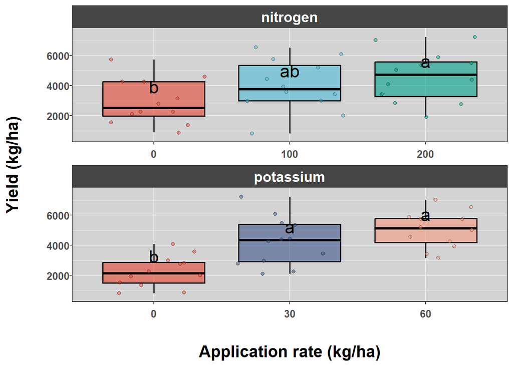

# Submitting your work

Once you have developed all the code and answers, make sure to Render this quarto file.

**Notes on rendering**:

- Make sure to render your work and inspect how the final html look like.
- If it does not look professional for whatever reason, then fix the issue, re-render it, recheck.
- Only send me your work once your html file looks professional.
  - **DO NOT** delete the file’s heading levels (# and ##). They set up the proper heading 1 and 2 levels, and I use them to guide my grading.
  - If a given chunk is also outputting warnings or messages, inhibit this behavior by changing the chunk options `message` and `warning` to `FALSE` (I’ll demo this in a moment).
  - If, after rendered, 2 lines of text are connected and you wish to “break line” between them, add 2 extra spaces after the first one (I’lld demo this in a moment).

After rendering, an .html file will be created on your `code` folder.

Rename this file to `Assignment-03-crd-LASTNAME.html`.

For ex., mine would be `Assignment-03-crd-Bastos.html`.

Send the **html** file to **lmbastos@uga.edu** by Feb 15th 11:59 pm.